# Parsing splicing events

Nuno Agostinho

20 November 2015

# Splicing events identifiers

The splicing events ID’s are different according to the program that creates it. The programs which allow to quantify expression levels of alternative splicing events and that are studied in this report are:

- [MISO](https://miso.readthedocs.org/en/fastmiso/)
- [SUPPA](https://bitbucket.org/regulatorygenomicsupf/suppa)
- [VAST-TOOLS](https://github.com/vastgroup/vast-tools)
- [MATS](http://rnaseq-mats.sourceforge.net)

It’s also important to understand that the splicing event ID’s may vary according to the splicing event type. The most common splicing event types annotated across the aforementioned programs are described in the following image (retrieved from the [SUPPA website](https://bitbucket.org/regulatorygenomicsupf/suppa)).

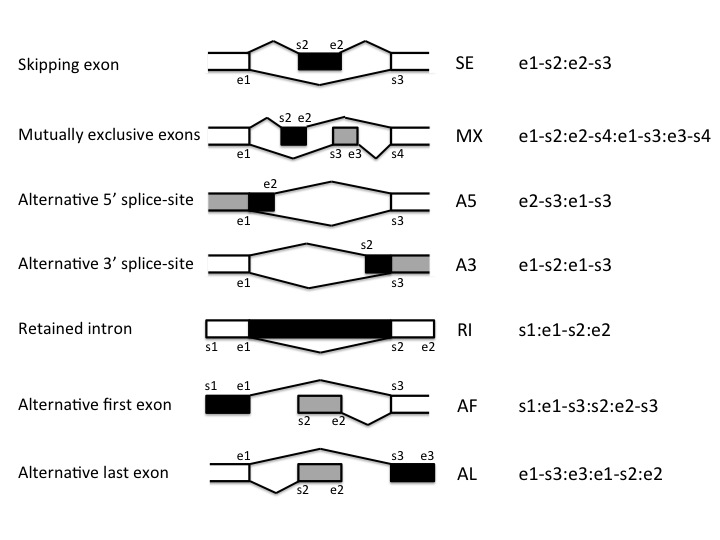

To conciliate the output from the different programs, it was decided to parse each splicing event ID to a R data type known as list with all the important attributes of an event, including:

- Species
- Chromosome
- Strand
- Gene
- mRNA
- Splicing event type

In order to store the events themselves, it’s possible to characterise all the represented splicing event types by using the boundaries of the following 4 exons:

- Upstream constitutive exon (C1)
- Upstram alternative exon (A1)
- Downstream alternative exon (A2)
- Downstream constitutive exon (C2)

The following table describes which positions should be stored to identify each splicing event type:

| Splicing event type | C1 start | C1 end | A1 start | A1 end | A2 start | A2 end | C2 start | C2 end |
| --- | --- | --- | --- | --- | --- | --- | --- | --- |
| Exon skipping |  | • | • | • |  |  | • |  |
| Mutually exclusive exons |  | • | • | • | • | • | • |  |
| Alternative 5’ splice site |  | • • |  |  |  |  | • |  |
| Alternative 3’ splice site |  | • |  |  |  |  | • • |  |
| Retained intron | • | • |  |  |  |  | • | • |
| Alternative first exon | • | • | • | • |  |  | • |  |
| Alternative last exon |  | • | • | • |  |  | • | • |

Note there are two glyphs in some cases. That means two alternative positions are stored (for example, in the case of the alternative 5’ splice site, the C1 end can alternatively be one of the two positions).

Before discussing how to parse thousands and thousands of events, we should reflect a bit on the tools available to compare different solutions that solve the same problem and how to measure performance on R. You can read about it in the article Measuring performance.

# Parsing splicing events from SUPPA

Let’s start to parse the splicing event types from SUPPA since they seem to be the easiest to parse. Below you can see for each type of event how SUPPA presents the respective event ID (includes gene, splicing event type, chromosome, positions of the exon junctions and strand).

| Splicing event type | Splicing event ID example from SUPPA |
| --- | --- |
| Exon skipping | ENSG00000000419;SE:20:49557470-49557642:49557746-49558568:- |
| Mutually exclusive exons | ENSG00000000419;MX:20:49557470-49557666:49557746-49562274:49557470-49558568:49558663-49562274:- |
| Alternative 5’ splice site | ENSG00000000003;A5:X:99890743-99891188:99890743-99891605:- |
| Alternative 3’ splice site | ENSG00000000419;A3:20:49557492-49557642:49557470-49557642:- |
| Retained intron | ENSG00000000971;RI:1:196709749:196709922-196711005:196711181:+ |
| Alternative first exon | ENSG00000000457;AF:1:169858031-169862929:169863076:169858031-169863148:169863408:- |
| Alternative last exon | ENSG00000001461;AL:1:24790610-24792494:24792800:24790610-24795476:24795797:+ |

Note that these splicing event ID’s can differ if SUPPA is run using the **-b V (variable)** option, where [“some variability is allowed in some of the boundaries”](https://bitbucket.org/regulatorygenomicsupf/suppa).

> TODO: account for the “variable” option in SUPPA events

But now there’s a question: how to parse them?

## Parsing the event attributes

### For loop

Don’t mind the parsing of the events at the moment, let’s just think on how to parse the attributes of an event. If we are going to receive a character vector of events, (maybe) we should be ready to parse each event. So, how about if we create a for loop to store each event’s attribute in their own vector?

```r
parseSuppaEventA <- function(event) {
  # split event ID by semicolon and colon symbols
  tmp <- strsplit(event, ";|:")

  # initialize empty character vectors to store event attributes
  gene <- character()
  event_type <- character()
  chromosome <- character()
  strand <- character()
  for (each in tmp) {
    # append value to vectors
    gene <- c(gene, each[[1]])
    event_type <- c(event_type, each[[2]])
    chromosome <- c(chromosome, each[[3]])

    len <- length(each)
    strand <- c(strand, each[[len]])
    # TODO: parse event itself
  }
  ret <- list(gene, event_type, chromosome, strand)
  names(ret) <- c("Gene", "Event type", "Chromosome", "Strand")
  return(ret)
}
```

### For loop with pre-filled vectors

Let’s try the same but using vectors already filled with NAs.

```r
parseSuppaEventB <- function(event) {
  # split event ID by semicolon and colon symbols
  tmp <- strsplit(event, ";|:")

  # initialize empty character vectors to store event attributes
  empty      <- rep(NA, length(event))
  gene       <- empty
  event_type <- empty
  chromosome <- empty
  strand     <- empty

  i <- 1
  for (each in tmp) {
    # replace value in vectors
    gene[i]       <- each[[1]]
    event_type[i] <- each[[2]]
    chromosome[i] <- each[[3]]

    len <- length(each)
    strand[i] <- each[[len]]
    i <- i+1
    # TODO: parse event itself
  }
  ret <- list(gene, event_type, chromosome, strand)
  names(ret) <- c("Gene", "Event type", "Chromosome", "Strand")
  return(ret)
}
```

Now, let’s compare the two methods.

```r
eventSE <- "ENSG00000000419;SE:20:49557470-49557642:49557746-49558568:-"
library(microbenchmark)
microbenchmark(
  parseSuppaEventA(eventSE),
  parseSuppaEventB(eventSE)
)
```

```
## Unit: microseconds
##                       expr    min      lq     mean  median      uq     max
##  parseSuppaEventA(eventSE) 29.018 31.5675 35.28547 32.7130 35.1995 101.705
##  parseSuppaEventB(eventSE) 31.968 33.9470 37.48129 35.1435 37.2705  58.631
##  neval cld
##    100  a
##    100   b
```

Hum, seems the first method is faster. I wasn’t expecting that…

### Apply function

Anyway, let’s adapt our code to use an apply function instead of a for loop. Since apply functions rely on C code, they ought to be faster than for loops.

```r
parseSuppaEventC <- function(event) {
  # split event ID by semicolon and colon symbols
  tmp <- strsplit(event, ";|:")

  # create a list of lists containing event information
  ret <- lapply(tmp, function(each) {
    len <- length(each)
    # create list with event attributes
    event_attrs <- list("Gene" = each[1],
                        "Event type" = each[2],
                        "Chromosome" = each[3],
                        "Strand" = each[len])
    # TODO: parse event itself
    return(event_attrs)
  })
  return(ret)
}

eventSE <- "ENSG00000000419;SE:20:49557470-49557642:49557746-49558568:-"
microbenchmark(
  parseSuppaEventA(eventSE),
  parseSuppaEventB(eventSE),
  parseSuppaEventC(eventSE)
)
```

```
## Unit: microseconds
##                       expr    min     lq     mean  median      uq     max
##  parseSuppaEventA(eventSE) 29.607 33.417 36.95901 35.2260 38.1520  59.703
##  parseSuppaEventB(eventSE) 34.802 36.738 41.36605 38.1165 40.4435  69.593
##  parseSuppaEventC(eventSE) 27.930 30.863 33.30335 31.8185 33.4340 102.237
##  neval cld
##    100  b
##    100   c
##    100 a
```

Seems this method is the fastest yet. Yay!

### One event at a time

Maybe we can also improve the code performance if our function only parses one event at a time. Let’s see…

```r
parseSuppaEventD <- function(event) {
  # Split event ID by semicolons and colons
  tmp <- strsplit(event, ";|:")[[1]]
  len <- length(tmp)

  # Get the attributes of the event
  event_attrs <- as.list(tmp[c(1:3, len)])
  names(event_attrs) <- c("Gene", "Event type", "Chromosome", "Strand")

  # TODO: parse event itself
  return(event_attrs)
}
```

```r
eventSE <- "ENSG00000000419;SE:20:49557470-49557642:49557746-49558568:-"
microbenchmark(
  parseSuppaEventA(eventSE),
  parseSuppaEventB(eventSE),
  parseSuppaEventC(eventSE),
  parseSuppaEventD(eventSE)
)
```

```
## Unit: microseconds
##                       expr    min      lq     mean  median      uq    max
##  parseSuppaEventA(eventSE) 31.468 34.0060 38.25262 35.7380 37.9785 98.938
##  parseSuppaEventB(eventSE) 34.376 36.8045 40.12843 38.3640 40.2165 78.691
##  parseSuppaEventC(eventSE) 28.851 31.5145 34.38984 33.1220 34.8345 89.079
##  parseSuppaEventD(eventSE) 33.260 36.0215 39.28335 37.8095 39.6675 71.283
##  neval cld
##    100   b
##    100   b
##    100  a
##    100   b
```

Nope, it seems this doesn’t work. Anyway, let’s see how our functions behave when dealing with 10000 events.

```r
events <- rep(eventSE, 10000)
library(rbenchmark)
benchmark(replications = 1,
          #for (e in events) t <-c(t,parseSuppaEventA(e)), ## too slow
          #for (e in events) t <-c(t,parseSuppaEventB(e)), ## too slow
          #for (e in events) t <-c(t,parseSuppaEventC(e)), ## too slow
          #for (e in events) t <-c(t,parseSuppaEventD(e)), ## too slow
          lapply(events, parseSuppaEventA),
          lapply(events, parseSuppaEventB),
          lapply(events, parseSuppaEventC),
          lapply(events, parseSuppaEventD),
          parseSuppaEventA(events),
          parseSuppaEventB(events),
          parseSuppaEventC(events)
)
```

```
##                               test replications elapsed relative user.self
## 1 lapply(events, parseSuppaEventA)            1   0.349    3.455     0.349
## 2 lapply(events, parseSuppaEventB)            1   0.378    3.743     0.378
## 3 lapply(events, parseSuppaEventC)            1   0.322    3.188     0.322
## 4 lapply(events, parseSuppaEventD)            1   0.374    3.703     0.373
## 5         parseSuppaEventA(events)            1   1.621   16.050     1.613
## 6         parseSuppaEventB(events)            1   0.132    1.307     0.129
## 7         parseSuppaEventC(events)            1   0.101    1.000     0.102
##   sys.self user.child sys.child
## 1    0.000          0         0
## 2    0.000          0         0
## 3    0.000          0         0
## 4    0.000          0         0
## 5    0.008          0         0
## 6    0.004          0         0
## 7    0.000          0         0
```

Interesting. It seems **parsing method C** is the fastest if we hand all the events as an argument (i.e. without using an exterior apply function).

## Parsing the junctions

The following function shows one way we could use to parse junctions. It simply splits junctions by the “-”, it reverses the junctions if it’s the minus strand, fills a list of parsed junctions with NAs and parses junction positions according to event type. Simple, right?

```r
parseSuppaJunctions <- function(event_type, strand, junctions) {
  # Split junctions by the hyphen symbol
  junctions <- strsplit(junctions, "-")
  junctions <- unlist(junctions)

  # If minus strand, reverse junctions
  if(strand == "-") junctions <- rev(junctions)

  # Fill list of parsed junctions with NAs
  parsed = list("C1 start" = NA, "C1 end" = NA,
                "A1 start" = NA, "A1 end" = NA,
                "A2 start" = NA, "A2 end" = NA,
                "C2 start" = NA, "C2 end" = NA)

  # Parse junction positions according to event type
  switch(event_type,
         "A3" = {
           parsed[["C1 end"]]   <- junctions[1]
           parsed[["C2 start"]] <- junctions[c(2,4)]
         },
         "A5" = {
           parsed[["C1 end"]]   <- junctions[c(3,1)]
           parsed[["C2 start"]] <- junctions[2]
         },
         "SE" = parsed[c("C1 end", "A1 start", "A1 end",
                         "C2 start")] <- junctions,
         "MX" = parsed[c("C1 end", "A1 start", "A1 end", "A2 start",
                         "A2 end", "C2 start")] <- junctions[-c(4,5)],
         "RI" = parsed[c("C1 start", "C1 end",
                         "C2 start", "C2 end")] <- junctions,
         "AF" = parsed[c("C1 start", "C1 end", "C2 end",
                         "A1 start", "A1 end")] <- junctions[1:5],
         "AL" = parsed[c("C2 start", "C2 end", "C1 start",
                         "A1 start", "A1 end")] <- junctions[2:6]
  )
  return(parsed)
}
```

Now, let’s use this function to complete parsing method C (henceforth mentioned as **parseSuppaEvent**).

```r
parseSuppaEvent <- function(event) {
  # Split event ID by semicolon and colon symbols
  tmp <- strsplit(event, ";|:")

  # Create a list of lists containing event information
  ret <- lapply(tmp, function(each) {
    len <- length(each)
    # Create list with event attributes
    event_attrs <- list("Gene" = each[1],
                        "Event type" = each[2],
                        "Chromosome" = each[3],
                        "Strand" = each[len])

    # Get the junction positions for each exon and parse them
    junctions <- each[4:(len-1)]
    parsed_junctions <- parseSuppaJunctions(event_attrs[["Event type"]],
                                            event_attrs[["Strand"]],
                                            junctions)
    return(c(event_attrs, parsed_junctions))
  })
  return(ret)
}

benchmark(replications = 1,
          parseSuppaEventC(events),
          parseSuppaEvent(events)
)
```

```
##                       test replications elapsed relative user.self
## 1 parseSuppaEventC(events)            1   0.103    1.000     0.103
## 2  parseSuppaEvent(events)            1   0.408    3.961     0.408
##   sys.self user.child sys.child
## 1        0          0         0
## 2        0          0         0
```

Well, our function with the addition takes about four times more to complete. Maybe we should try to optimise the code we just add. What if we used the classic if/else instead of the switch?

```r
parseSuppaJunctions <- function(event_type, strand, junctions) {
  # Split junctions by the hyphen
  junctions <- strsplit(junctions, "-")
  junctions <- unlist(junctions)

  # If minus strand, reverse junctions
  if(strand == "-") junctions <- rev(junctions)

  # Fill list of parsed junctions with NAs
  parsed = list("C1 start" = NA, "C1 end" = NA,
                "A1 start" = NA, "A1 end" = NA,
                "A2 start" = NA, "A2 end" = NA,
                "C2 start" = NA, "C2 end" = NA
  )

  # Parse junction positions according to event type
  if (event_type == "A3") {
    parsed[["C1 end"]]   <- junctions[1]
    parsed[["C2 start"]] <- junctions[c(2,4)]
  } else if (event_type == "A5") {
    parsed[["C1 end"]]   <- junctions[c(3,1)]
    parsed[["C2 start"]] <- junctions[2]
  } else if (event_type == "SE") {
    parsed[c("C1 end", "A1 start", "A1 end",
             "C2 start")] <- junctions
  } else if (event_type == "MX") {
    parsed[c("C1 end", "A1 start", "A1 end", "A2 start",
             "A2 end", "C2 start")] <- junctions[-c(4,5)]
  } else if (event_type == "RI") {
    parsed[c("C1 start", "C1 end",
             "C2 start", "C2 end")] <- junctions
  } else if (event_type == "AF") {
    parsed[c("C1 start", "C1 end", "C2 end",
             "A1 start", "A1 end")] <- junctions[1:5]
  } else if (event_type == "AL") {
    parsed[c("C2 start", "C2 end", "C1 start",
             "A1 start", "A1 end")] <- junctions[2:6]
  }
  return(parsed)
}

benchmark(replications = 1,
          parseSuppaEventC(events),
          parseSuppaEvent(events)
)
```

```
##                       test replications elapsed relative user.self
## 1 parseSuppaEventC(events)            1   0.132    1.000     0.133
## 2  parseSuppaEvent(events)            1   0.551    4.174     0.531
##   sys.self user.child sys.child
## 1     0.00          0         0
## 2     0.02          0         0
```

The if/else doesn’t seem to make much difference, the difference is still about four times slower. Maybe we don’t need to `unlist` the result of `strsplit`? Maybe we should try to rewrite the function without using the `unlist` function? Let’s do it in another day, shall we?

> TODO: more performance tweaks

# Parsing splicing events from MISO

To get expression levels using MISO, you only need to give it alternative events annotation files (in the GFF3 format) and a sample BAM file.

Splicing event ID’s from MISO don’t differ that much from those in SUPPA, although they don’t contain gene names nor type of event, as you can see from the following table (notice that Tandem UTR is a type of event which is not present in SUPPA).

| Splicing event type | Splicing event ID example from SUPPA |
| --- | --- |
| Exon skipping | chr19:14069173:14069295:-@chr19:14065440:14065604:-@chr19:14063500:14065049:- |
| Mutually exclusive exons | chr2:261866:261939:+@chr2:262037:262150:+@chr2:262192:262305:+@chr2:265140:265630:+ |
| Alternative 5’ splice site | chr22:41353339:41353254 |
| Alternative 3’ splice site | chr4:156848838:156848896:+@chr4:156851144 |
| Retained intron | chr3:151768379:151768406:+@chr3:151768494:151768523:+ |
| Alternative first exon | 2217@uc002poi.1@uc002poe.1 |
| Alternative last exon | 55814@uc003msh.1uc003msk.1@uc003msj.1 |
| Tandem UTR | chr17:53778273:53778604:-@chr17:53777536:53778272:- |

The splicing event ID’s were originally attributed using the Human genome’s 18th assembly or the Mouse genome’s 8th assembly. To create the GFF3 annotation files relative to the newer assemblies of the Human and Mouse genomes, they used [UCSC’s liftOver](https://genome.ucsc.edu/cgi-bin/hgLiftOver) to change the positions (but the ID’s stayed the same). Therefore, we need to cross-ref the annotation files with the splicing event ID’s to parse the splicing events and to get the expression levels.

Another thing to note is that MISO can also return isoform-centric analyses and may be important to expect and parse isoform-centric events.

> TODO: parse MISO’s isoform-centric events

## Cross-referencing the splicing event ID’s

This one seems easy enough. For each splicing event ID, just get any matches in the alternative splicing annotation files.

### grep

```r
eventID <- "2217@uc002poi.1@uc002poe.1"
annotation <- read.delim(
  "/genedata/Resources/Annotations/MISO/hg19/AFE.hg19.gff3",
  header=FALSE, comment.char="#")
IDindex <- 9 # index of the column with the event ID's in the annotation file

matchMisoEvent1 <- function(eventID, annotation, IDindex) {
  # Get lines matching to a given MISO splicing event ID
  match <- grep(eventID, annotation[[IDindex]], fixed = TRUE)
  annotation[match,]
}
```

The resulting output is shown in the table below.

| V1 | V2 | V3 | V4 | V5 | V6 | V7 | V8 | V9 |
| --- | --- | --- | --- | --- | --- | --- | --- | --- |
| chr19 | AFE | gene | 50015886 | 50028830 | . | + | . | ID=2217@uc002poi.1@uc002poe.1;Name=2217@uc002poi.1@uc002poe.1;gid=2217@uc002poi.1@uc002poe.1 |
| chr19 | AFE | mRNA | 50028313 | 50028830 | . | + | . | ID=2217@uc002poi.1@uc002poe.1.A;Parent=2217@uc002poi.1@uc002poe.1;Name=2217@uc002poi.1@uc002poe.1.A;gid=2217@uc002poi.1@uc002poe.1 |
| chr19 | AFE | exon | 50028313 | 50028830 | . | + | . | ID=2217@uc002poi.1@uc002poe.1.A.0;Parent=2217@uc002poi.1@uc002poe.1.A;Name=2217@uc002poi.1@uc002poe.1.A.0;gid=2217@uc002poi.1@uc002poe.1 |
| chr19 | AFE | mRNA | 50015886 | 50016730 | . | + | . | ID=2217@uc002poi.1@uc002poe.1.B;Parent=2217@uc002poi.1@uc002poe.1;Name=2217@uc002poi.1@uc002poe.1.B;gid=2217@uc002poi.1@uc002poe.1 |
| chr19 | AFE | exon | 50015886 | 50016007 | . | + | . | ID=2217@uc002poi.1@uc002poe.1.B.0;Parent=2217@uc002poi.1@uc002poe.1.B;Name=2217@uc002poi.1@uc002poe.1.B.0;gid=2217@uc002poi.1@uc002poe.1 |
| chr19 | AFE | exon | 50016644 | 50016730 | . | + | . | ID=2217@uc002poi.1@uc002poe.1.B.1;Parent=2217@uc002poi.1@uc002poe.1.B;Name=2217@uc002poi.1@uc002poe.1.B.1;gid=2217@uc002poi.1@uc002poe.1 |

Let’s see how long it takes to get one event:

```r
microbenchmark(times = 1,
               matchMisoEvent1(eventID, annotation, IDindex),
               lapply(rep(eventID,3), matchMisoEvent1, annotation, IDindex))
```

```
## Unit: milliseconds
##                                                           expr      min
##                  matchMisoEvent1(eventID, annotation, IDindex) 138.5971
##  lapply(rep(eventID, 3), matchMisoEvent1, annotation, IDindex) 414.7152
##        lq     mean   median       uq      max neval
##  138.5971 138.5971 138.5971 138.5971 138.5971     1
##  414.7152 414.7152 414.7152 414.7152 414.7152     1
```

Cross-refering three MISO events with the alternative splicing annotation takes the same time needed to parse 10000 events from SUPPA. If the annotation file has the annotation of all event types from MISO (and not just one event type as in this test), it can take as long as 3 seconds to match each event.

### pmatch

Maybe `grep` is just too slow and we should look for another function. As we can see in the table above, column V9 has the ID we’d like after `ID=`. Maybe we could try to use `pmatch`. But since this function doesn’t return more than one finding, let’s use it to find the first matching ID and from there we can look for the others.

```r
getMisoEvent <- function(index, annotation) {
  # Get all lines before next gene
  next_index <- match("gene", tail(annotation[[3]], index))
  seq <- seq(index, index + next_index + 1)
  return(annotation[seq, ])
}

matchMisoEvent2 <- function(eventID, annotation, IDindex) {
  # Get first line matching a given splicing event ID
  match <- pmatch(paste0("ID=", eventID, ";"),
                  annotation[[IDindex]], duplicates.ok = TRUE)
  # Get all lines related to a given splicing event
  lapply(match, getMisoEvent, annotation)
}

microbenchmark(times = 1,
               matchMisoEvent2(rep(eventID,1), annotation, IDindex),
               matchMisoEvent2(rep(eventID,100), annotation, IDindex))
```

```
## Unit: milliseconds
##                                                     expr       min
##    matchMisoEvent2(rep(eventID, 1), annotation, IDindex)  16.01357
##  matchMisoEvent2(rep(eventID, 100), annotation, IDindex) 842.42521
##         lq      mean    median        uq       max neval
##   16.01357  16.01357  16.01357  16.01357  16.01357     1
##  842.42521 842.42521 842.42521 842.42521 842.42521     1
```

#### Calculate next gene index

What if instead of looking for the index of the next gene each time, the index of all genes is found at once? Then we could ask for the index of the next gene.

```r
getMisoEventB <- function(index, annotation, genes_index) {
  # Get all lines before next gene
  next_gene <- genes_index[genes_index > index][1]
  seq <- seq(index, next_gene - 1)
  return(annotation[seq, ])
}

matchMisoEvent2B <- function(eventID, annotation, IDcolumn) {
  # Get first line matching a given splicing event ID
  index <- pmatch(paste0("ID=", eventID, ";"),
                  annotation[[IDcolumn]], duplicates.ok = TRUE)
  # Get all lines related to a given splicing event
  genes_index <- which(annotation[["V3"]] == "gene")
  # Get index of the next gene
  next_index <- genes_index[match(index, genes_index) + 1]
  lapply(index, getMisoEventB, annotation, genes_index)
}

microbenchmark(times = 1,
               matchMisoEvent2B(rep(eventID,1), annotation, IDindex),
               matchMisoEvent2B(rep(eventID,100), annotation, IDindex))
```

```
## Unit: milliseconds
##                                                      expr       min
##    matchMisoEvent2B(rep(eventID, 1), annotation, IDindex)  24.18106
##  matchMisoEvent2B(rep(eventID, 100), annotation, IDindex) 735.67040
##         lq      mean    median        uq       max neval
##   24.18106  24.18106  24.18106  24.18106  24.18106     1
##  735.67040 735.67040 735.67040 735.67040 735.67040     1
```

#### Match each gene to get the index of the following gene

To get faster times, how about looking for our index of interest in the genes index and incrementing one to get the next gene index?

```r
getMisoEventC <- function(index, annotation, genes_index) {
  # Get all lines before next gene
  next_index <- genes_index[match(index, genes_index) + 1]
  seq <- seq(index, next_index - 1)
  return(annotation[seq, ])
}

matchMisoEvent2C <- function(eventID, annotation, IDcolumn) {
  # Get first line matching a given splicing event ID
  index <- pmatch(paste0("ID=", eventID, ";"),
                  annotation[[IDcolumn]], duplicates.ok = TRUE)
  # Get all lines related to a given splicing event
  genes_index <- which(annotation[["V3"]] == "gene")
  lapply(index, getMisoEventC, annotation, genes_index)
}

microbenchmark(times = 1,
               matchMisoEvent2C(rep(eventID,1), annotation, IDindex),
               matchMisoEvent2C(rep(eventID,100), annotation, IDindex))
```

```
## Unit: milliseconds
##                                                      expr       min
##    matchMisoEvent2C(rep(eventID, 1), annotation, IDindex)  31.35312
##  matchMisoEvent2C(rep(eventID, 100), annotation, IDindex) 726.70679
##         lq      mean    median        uq       max neval
##   31.35312  31.35312  31.35312  31.35312  31.35312     1
##  726.70679 726.70679 726.70679 726.70679 726.70679     1
```

#### Match all genes at once to get the index of the following genes

Better yet, let’s find all next genes index at the same time!

```r
getMisoEventD <- function(i, annotation, index, next_index) {
  # Get all lines before next gene
  seq <- seq(index[i], next_index[i] - 1)
  return(annotation[seq, ])
}

matchMisoEvent2D <- function(eventID, annotation, IDcolumn) {
  # Get first line matching a given splicing event ID
  index <- pmatch(paste0("ID=", eventID, ";"),
                  annotation[[IDcolumn]], duplicates.ok = TRUE)
  # Get all lines related to a given splicing event
  genes_index <- which(annotation[["V3"]] == "gene")
  # Get index of the next gene
  next_index <- genes_index[match(index, genes_index) + 1]
  lapply(1:length(index), getMisoEventD, annotation, index, next_index)
}

microbenchmark(times = 1,
               matchMisoEvent2D(rep(eventID,1), annotation, IDindex),
               matchMisoEvent2D(rep(eventID,100), annotation, IDindex))
```

```
## Unit: milliseconds
##                                                      expr       min
##    matchMisoEvent2D(rep(eventID, 1), annotation, IDindex)  30.91202
##  matchMisoEvent2D(rep(eventID, 100), annotation, IDindex) 650.13988
##         lq      mean    median        uq       max neval
##   30.91202  30.91202  30.91202  30.91202  30.91202     1
##  650.13988 650.13988 650.13988 650.13988 650.13988     1
```

Seems this method is the fastest.

### match

Since the first matching ID is a common expression, we’ll see if the `match` function is faster than `pmatch`.

```r
matchMisoEvent3 <- function(eventID, annotation, IDindex) {
  # Get first line matching a given splicing event ID
  match <- match(paste0("ID=", eventID, ";Name=", eventID, ";gid=", eventID),
                 annotation[[IDindex]])
  # Get all lines related to a given splicing event
  lapply(match, getMisoEvent, annotation)
}

microbenchmark(times = 1,
               matchMisoEvent3(rep(eventID,1), annotation, IDindex),
               matchMisoEvent3(rep(eventID,100), annotation, IDindex),
               matchMisoEvent3(rep(eventID,10000), annotation, IDindex))
```

```
## Unit: milliseconds
##                                                       expr         min
##      matchMisoEvent3(rep(eventID, 1), annotation, IDindex)    13.32418
##    matchMisoEvent3(rep(eventID, 100), annotation, IDindex)   253.46697
##  matchMisoEvent3(rep(eventID, 10000), annotation, IDindex) 26756.99912
##           lq        mean      median          uq         max neval
##     13.32418    13.32418    13.32418    13.32418    13.32418     1
##    253.46697   253.46697   253.46697   253.46697   253.46697     1
##  26756.99912 26756.99912 26756.99912 26756.99912 26756.99912     1
```

Another thing we could try is to create a vector exclusively with the ID in the column V9 from the annotation file and do a simple `match`.

> TODO

### which

Let’s also check if `which` is faster than `match`.

```r
matchMisoEvent4 <- function(eventID, annotation, IDindex) {
  # Get first line matching a given splicing event ID
  match <- which(annotation[[IDindex]] == paste0("ID=", eventID,
                                                     ";Name=", eventID,
                                                     ";gid=", eventID))
  # Get all lines related to a given splicing event
  lapply(match, getMisoEvent, annotation)
}

microbenchmark(times = 1,
               lapply(rep(eventID,1), matchMisoEvent4, annotation, IDindex),
               lapply(rep(eventID,10), matchMisoEvent4, annotation, IDindex)
)
```

```
## Unit: milliseconds
##                                                            expr       min
##   lapply(rep(eventID, 1), matchMisoEvent4, annotation, IDindex)  17.59248
##  lapply(rep(eventID, 10), matchMisoEvent4, annotation, IDindex) 185.45568
##         lq      mean    median        uq       max neval
##   17.59248  17.59248  17.59248  17.59248  17.59248     1
##  185.45568 185.45568 185.45568 185.45568 185.45568     1
```

Well, it seems that it takes too much just for 10 events. Nevermind about using this function.

### Using liftOver

Yet another way to parse MISO splicing event IDs is to do it just like we parsed SUPPA IDs and then use `liftOver` to convert the coordinates from the Human genome’s 18th assembly or Mouse genome’s 8th assembly to the correct one. This may be a problem if the ID doesn’t mean anything like in the cases of two splicing event types: alternative first and last exon.

> TODO